# Exponential Smoothing on Australian Wine Dataset

Sambridee Mahat

2026-03-02

## Introduction

The Australian Wines dataset contains the monthly sales volume (in thousands of litres) for six different wine types: Fortified, Red, Rose, Sparkling, Sweet White, and Dry White. The dataset spans January 1980 to December 1994, containing 180 monthly observations. Red wine was selected for this analysis because its time series exhibits three key characteristics that make it well-suited for exponential smoothing: a clear upward trend, strong 12-month seasonality, and multiplicative seasonal behaviour where the amplitude of seasonal swings grows proportionally with the level of the series.

The objective is to forecast monthly red wine sales using a range of ETS (Error-Trend-Seasonality) smoothing models and evaluate how well each model performs against a seasonal naïve benchmark.

```r
# Directory
setwd("C:/Users/samri/OneDrive/Desktop/ECON 6635 Business Forecasting/Week 5")
# ── Read CSV & create a tsibble ──
wines_raw <- read.csv("AustralianWines.csv") |>
  mutate(Month = yearmonth(my(Month))) |>      # my() parses "Jan-80" → Date, then yearmonth()
  as_tsibble(index = Month)                    # declare time index → R "knows" it's a time series

# Quick data checks
glimpse(wines_raw)
```

```
## Rows: 180
## Columns: 7
## $ Month       <mth> 1980 Jan, 1980 Feb, 1980 Mar, 1980 Apr, 1980 May, 1980 Jun…
## $ Fortified   <int> 2585, 3368, 3210, 3111, 3756, 4216, 5225, 4426, 3932, 3816…
## $ Red         <int> 464, 675, 703, 887, 1139, 1077, 1318, 1260, 1120, 963, 996…
## $ Rose        <int> 112, 118, 129, 99, 116, 168, 118, 129, 205, 147, 150, 267,…
## $ Sparkling   <int> 1686, 1591, 2304, 1712, 1471, 1377, 1966, 2453, 1984, 2596…
## $ Sweet.white <int> 85, 89, 109, 95, 91, 95, 96, 128, 124, 111, 178, 140, 150,…
## $ Dry.white   <int> 1954, 2302, 3054, 2414, 2226, 2725, 2589, 3470, 2400, 3180…
```

```r
# Focus on Red Wine
red <- wines_raw |>
  select(Month, Red)
```

## Data Exploration

### Step 1: Visualize & Decompose

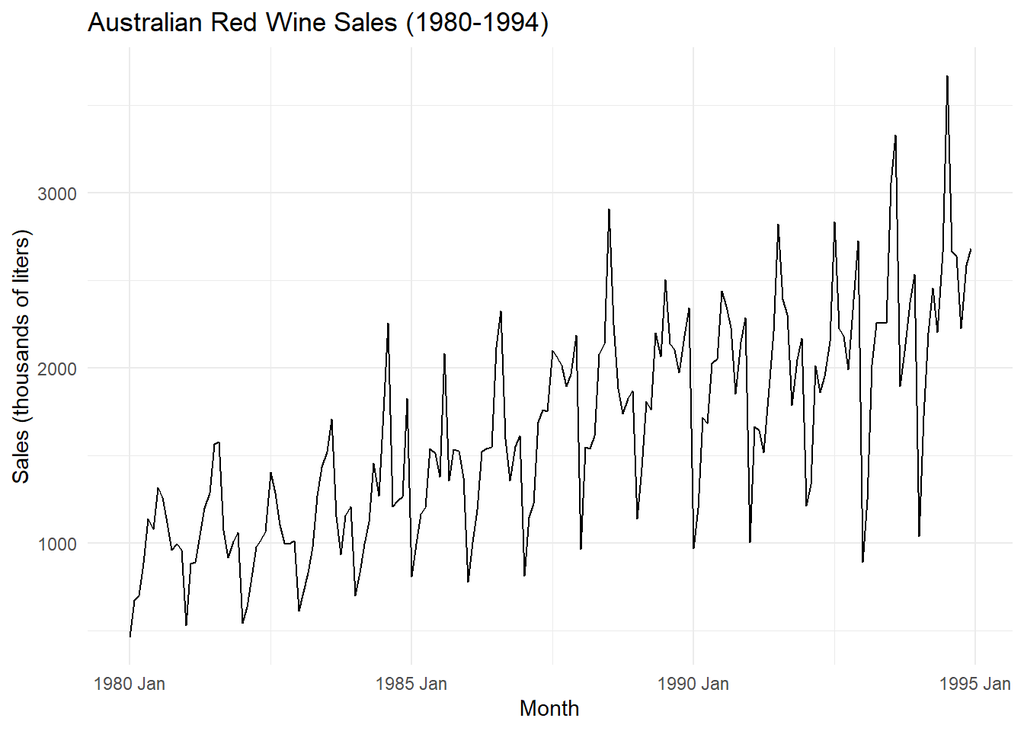

```r
# ── Time series plot ──────────────────────────────────────────────────────────
autoplot(red, Red) +
  labs(title = "Australian Red Wine Sales (1980-1994)",
       y = "Sales (thousands of liters)",
       x = "Month") +
  theme_minimal()
```

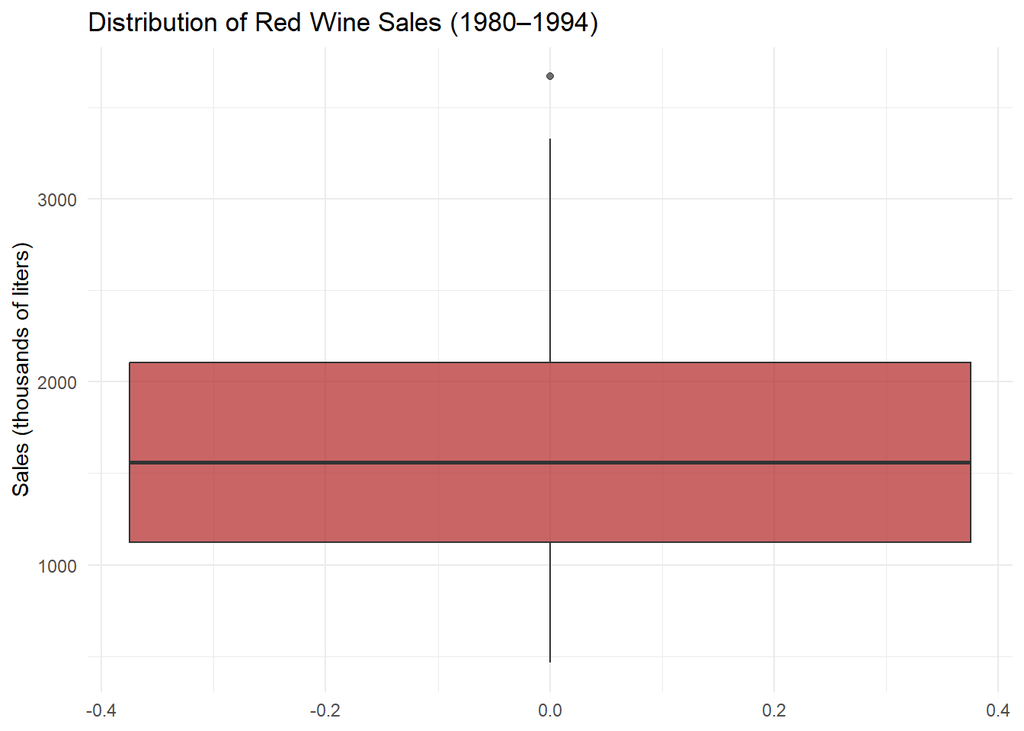

```r
# ── Boxplot────────────────────────────────────────────────────────────────────
red |>
  ggplot(aes(y = Red)) +
  geom_boxplot(fill = "firebrick", alpha = 0.7) +
  labs(title = "Distribution of Red Wine Sales (1980–1994)",
       y = "Sales (thousands of liters)") +
  theme_minimal()
```

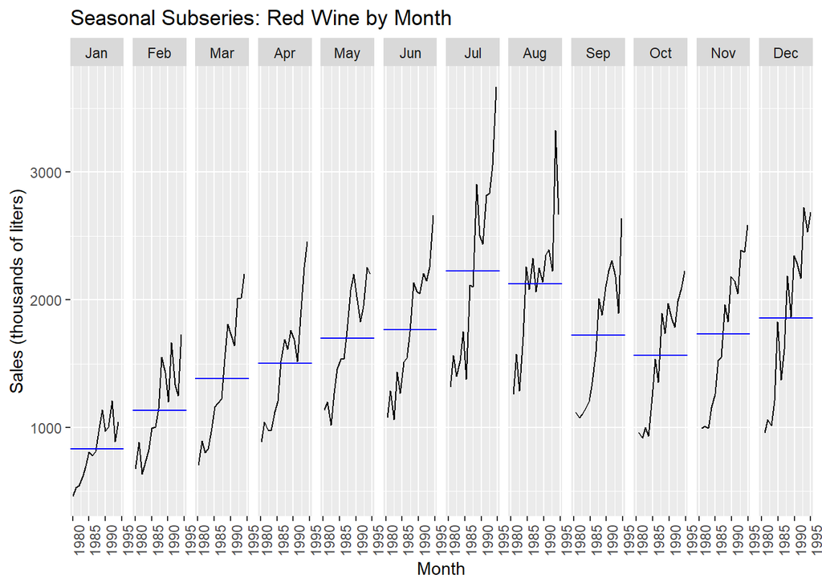

```r
# ── Seasonal subseries plot (feasts package) ──────────────────────────────────
red |>
  gg_subseries(Red) +
  labs(title = "Seasonal Subseries: Red Wine by Month",
       y = "Sales (thousands of liters)")
```

The seasonal subseries plot shows the full time series within each month alongside its monthly average (the horizontal blue line). July and August have the highest average sales and also show the steepest upward trajectories over time. January and February consistently have the lowest averages.Every month shows an upward trend from 1980 to 1994, confirming that the long-run growth is pervasive across all seasons rather than being driven by one particular time of year.

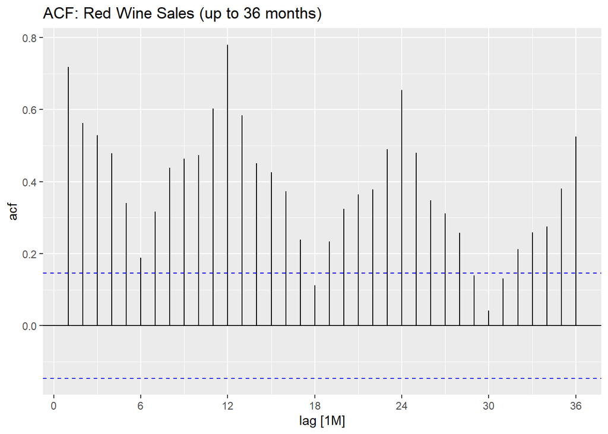

```r
# ── ACF plot (same idea as Baregg, but now checking for lag-12) ───────────────
red |>
  ACF(Red, lag_max = 36) |>
  autoplot() +
  labs(title = "ACF: Red Wine Sales (up to 36 months)")
```

The spikes at the lag 12, 24, 36 suggest that the pattern repeats each year signifying monthly seasonality. The slow, gradual decay of autocorrelation between seasonal peaks (rather than a sharp drop) is characteristic of a series with both a strong trend and seasonality. Also, most of the bars are outside the blue line which suggest that there is pattern to be uncovered from the data and it is not random.

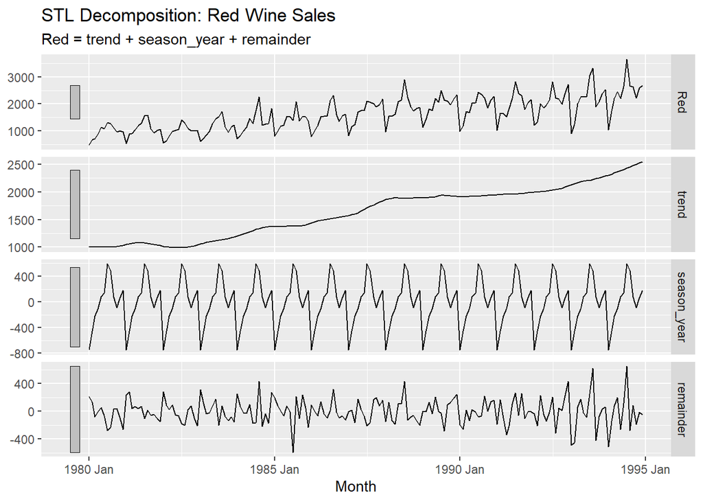

```r
# ── STL decomposition ────────────────────────────────────────────────────────
# STL = Seasonal and Trend decomposition using Loess (pronounced LOW-ess)

red |>
  model(STL(Red ~ trend(window = 21) +
              season(window = "periodic"))) |>
  components() |>
  autoplot() +
  labs(title = "STL Decomposition: Red Wine Sales")
```

The **remainder component** is largely random, with most values falling within ±400 thousand litres and no obvious systematic pattern, though a few larger spikes are visible.

## Methodology

### Step 2: Partition

```r
# SECTION 3: PARTITION INTO TRAINING & VALIDATION
# ═══════════════════════════════════════════════════════════════════════════════
train <- red |> filter(year(Month) < 1994)      # 1980-01 to 1993-12 (168 months)
valid <- red |> filter(year(Month) >= 1994)      # 1994-01 to 1994-12 (12 months)

cat("Training:", nrow(train), "months\n")
```

```
## Training: 168 months
```

```r
cat("Validation:", nrow(valid), "months\n")
```

```
## Validation: 12 months
```

The dataset is partitioned into a training set covering January 1980 through December 1993 (168 months) and a validation set covering all 12 months of 1994. All models are fitted exclusively on the training data, and forecasts for the 12-month validation window are then compared against the actual 1994 observations.

### Step 3: Fit Models

```r
# SECTION 4: FIT SMOOTHING MODELS WITH ETS
# ═══════════════════════════════════════════════════════════════════════════════
fit <- train |>
  model(
    # ── Benchmark ────────────────────────────────────────────────────────────
    snaive   = SNAIVE(Red),                                          # seasonal naive (MASE = 1.0 by definition)

    # ── Smoothing models (Ch5) ──
    ses      = ETS(Red ~ error("A") + trend("N") + season("N")),     # Simple Exponential Smoothing: level only
    holt     = ETS(Red ~ error("A") + trend("A") + season("N")),     # Holt's Linear: level + trend
    hw_add   = ETS(Red ~ error("A") + trend("A") + season("A")),     # Holt-Winters Additive
    hw_mult  = ETS(Red ~ error("A") + trend("A") + season("M")),     # Holt-Winters Multiplicative
    hw_damped= ETS(Red ~ error("A") + trend("Ad") + season("M"))     # HW Multiplicative + Damped trend
  )

# ── View all fitted parameters ───────────────────────────────────────────────
fit |>
  tidy() |>
  print(n = 50)
```

```
## # A tibble: 58 × 6
##    .model    term      estimate std.error statistic p.value
##    <chr>     <chr>        <dbl>     <dbl>     <dbl>   <dbl>
##  1 ses       alpha     0.588           NA        NA      NA
##  2 ses       l[0]    574.              NA        NA      NA
##  3 holt      alpha     0.581           NA        NA      NA
##  4 holt      beta      0.000100        NA        NA      NA
##  5 holt      l[0]    668.              NA        NA      NA
##  6 holt      b[0]     11.0             NA        NA      NA
##  7 hw_add    alpha     0.115           NA        NA      NA
##  8 hw_add    beta      0.000100        NA        NA      NA
##  9 hw_add    gamma     0.000100        NA        NA      NA
## 10 hw_add    l[0]   1016.              NA        NA      NA
## 11 hw_add    b[0]      7.43            NA        NA      NA
## 12 hw_add    s[0]    184.              NA        NA      NA
```

[output cut: 39 more lines]

```r
# Compare the optimized alpha, beta, gamma to textbook defaults (0.2, 0.15, 0.05)
```

#### The ETS Model Family

1. **Simple Exponential Smoothing (SES):** This is the simplest model, designed for “level-only” (α) series that lack a clear trend or seasonality. It uses exponentially decaying weights, where the most recent observations have the most influence on the forecast.
2. **Holt’s Linear Trend:** This model adds a trend component with parameter β, but still ignores seasonality, so it is also expected to underperform on this data.
3. **Holt-Winters (Triple Smoothing):** This model incorporates all three components (level, trend, and seasonality), adding a third parameter (γ) for seasonality.

It has two main variants: i. **Additive (hw_add):** when seasonal swings are constant regardless of the level. ii. **Multiplicative (hw_mult):** Used when seasonal waves grow or shrink proportionally as the sales level rises or falls. This is the theoretically preferred specification given the growing amplitude observed in the data.

4. **Damped Trend (hw_damped):** This variant adds a damping parameter (ϕ) to the Holt-Winters model, which “dampens” the trend into the future so that it eventually flattens out rather than continuing linearly forever.

**SNAIVE as the Benchmark:** The Seasonal Naïve (SNAIVE) model serves as the essential benchmark because it represents the simplest possible seasonal forecasting rule: assuming that the value for a given month will be exactly the same as it was in the same month of the previous year.

Across all seasonal models, the trend (β) and seasonal (γ) smoothing parameters converge to near-zero values (around 0.0001), indicating that the trend slope and seasonal pattern are extremely stable over time and update very slowly. The level parameter α is notably higher for the simpler models (SES: 0.588, Holt: 0.581) compared to the seasonal models (hw_add: 0.115, hw_mult: 0.174), reflecting that without seasonal components, these models must rely more heavily on recent observations to track the series. The damping parameter φ = 0.975 in the damped model is close to 1, suggesting the trend is only mildly dampened.

```r
# ── Information criteria (AIC/AICc/BIC) ──────────────────────────────────────
fit |>
  glance() |>
  select(.model, AIC, AICc, BIC) |>
  arrange(AICc)
```

```
## # A tibble: 6 × 4
##   .model      AIC  AICc   BIC
##   <chr>     <dbl> <dbl> <dbl>
## 1 hw_mult   2634. 2638. 2687.
## 2 hw_damped 2635. 2640. 2692.
## 3 hw_add    2667. 2671. 2720.
## 4 ses       2882. 2882. 2892.
## 5 holt      2886. 2886. 2902.
## 6 snaive      NA    NA    NA
```

```r
# Lower AICc = better balance of fit vs complexity
```

Looking at the accuracy table, I predict Holt-Winters Multiplicative model will perform best because it has lower values across all three criterias of our models (AIC, AICc, BIC). The damped trend model doesn’t outperform the standard Holt-Winters Multiplicative here because our data has strong upward trend and damping the model is hurting since damping flattens the forecast curve as the horizon extends.

## Results

### Step 4: Measure Accuracy

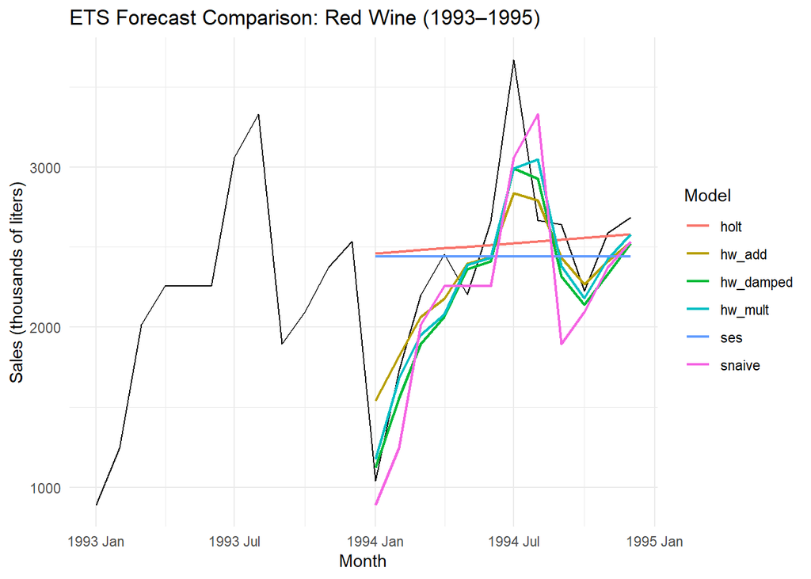

```r
# SECTION 5: FORECAST & EVALUATE
# ═══════════════════════════════════════════════════════════════════════════════

# ── Generate forecasts (reuses fit — no refitting!) ───────────────────────────
fc <- fit |> forecast(h = 12)

# ── Plot forecasts vs actuals ─────────────────────────────────────────────────
fc_plot <- fc |>
  as_tibble() |>
  select(.model, Month, .mean)

ggplot() +
  autolayer(filter(red, year(Month) >= 1993), Red, color = "black") +
  geom_line(data = fc_plot, aes(x = Month, y = .mean, color = .model), linewidth = 0.8) +
  labs(title = "ETS Forecast Comparison: Red Wine (1993–1995)",
       y = "Sales (thousands of liters)",
       x = "Month",
       color = "Model") +
  theme_minimal()
```

```r
# ── Accuracy table (THE PAYOFF FROM Baregg) ───────────────────────────────────
acc <- accuracy(fc, red) |>
  select(.model, ME, RMSE, MAE, MAPE, MASE) |>
  arrange(MASE)

print(acc)
```

```
## # A tibble: 6 × 6
##   .model        ME  RMSE   MAE  MAPE  MASE
##   <chr>      <dbl> <dbl> <dbl> <dbl> <dbl>
## 1 hw_mult    121.   292.  238.  9.50  1.21
## 2 hw_add      88.2  323.  246. 11.5   1.25
## 3 hw_damped  177.   303.  260. 10.3   1.32
## 4 snaive     212.   403.  332. 13.8   1.69
## 5 holt      -123.   592.  395. 22.6   2.01
## 6 ses        -45.0  603.  423. 23.3   2.15
```

```r
# ── Head-to-head: best ETS vs SNAIVE ──────────────────────────────────────────
best_model_name <- acc$.model[1]
cat("\nBest model:", best_model_name, "\n")
```

```
##
## Best model: hw_mult
```

```r
cat("MASE:", acc$MASE[acc$.model == best_model_name], "\n")
```

```
## MASE: 1.210202
```

### Step 5: Diagnose Residuals

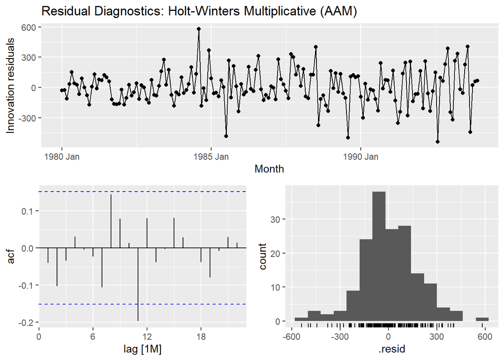

```r
# SECTION 6: RESIDUAL DIAGNOSTICS
# ══════════════════════════════════════════════════════════════════════════════

# ── Extract hw_mult from the ALREADY-FITTED models ────────────────────────────
best_fit <- fit |> select(hw_mult)

# ── 3-panel residual diagnostics ──────────────────────────────────────────────
best_fit |>
  gg_tsresiduals() +
  labs(title = "Residual Diagnostics: Holt-Winters Multiplicative (AAM)")
```

The three-panel residual diagnostic plot examines whether the Holt-Winters Multiplicative model has successfully extracted all systematic structure from the data.

The **time plot of innovation residuals** shows values scattered randomly around zero throughout the 1980–1993 training period, with no obvious upward or downward drift and no persistent runs in one direction. There is some evidence of slightly increasing residual variance in the late 1980s and early 1990s, which is consistent with the multiplicative structure of the series — even after accounting for multiplicative seasonality.

The **ACF of residuals** shows all autocorrelation lags falling within the 95% significance bands, except for one lag at 11. This is a strong indicator that the model has successfully removed both the trend and the 12-month seasonal autocorrelation structure from the data.

The **histogram of residuals** is approximately bell-shaped and centred close to zero. The distribution has slightly heavier tails than a perfect normal, which may be partly attributable to the few extreme spike months noted in the time plot.

```r
# ── Ljung-Box test (formal version of the ACF check) ──────────────────────────
lb_result <- best_fit |>
  augment() |>
  features(.innov, ljung_box, lag = 24)

print(lb_result)
```

```
## # A tibble: 1 × 3
##   .model  lb_stat lb_pvalue
##   <chr>     <dbl>     <dbl>
## 1 hw_mult    21.6     0.600
```

```r
# ── Compare Ljung-Box across models (reuses fit — no refitting!) ─────────────
fit |>
  select(snaive, hw_add, hw_mult, hw_damped) |>
  augment() |>
  features(.innov, ljung_box, lag = 24)
```

```
## # A tibble: 4 × 3
##   .model    lb_stat lb_pvalue
##   <chr>       <dbl>     <dbl>
## 1 hw_add       30.0  0.185
## 2 hw_damped    20.6  0.663
## 3 hw_mult      21.6  0.600
## 4 snaive       55.9  0.000234
```

**The Ljung-Box p-value** is used to determine whether data is randomly distributed or exhibit some significant autocorrelation. Ho: residuals are white noise Ha: autocorrelation is present

For, hw_mult, the p-value is 0.6, which is greater than 0.05. Therefore, we don’t have enough evidence to reject the null hypothesis. It implies the residuals are random and it has extracted everything statistically extractable from the data.

The cross-model Ljung-Box comparison is instructive. All three ETS seasonal models (hw_add: p = 0.185, hw_damped: p = 0.663, hw_mult: p = 0.600) pass the white noise test comfortably. The seasonal naïve model, by contrast, fails the test with a p-value of 0.000234, indicating its residuals retain significant autocorrelation.

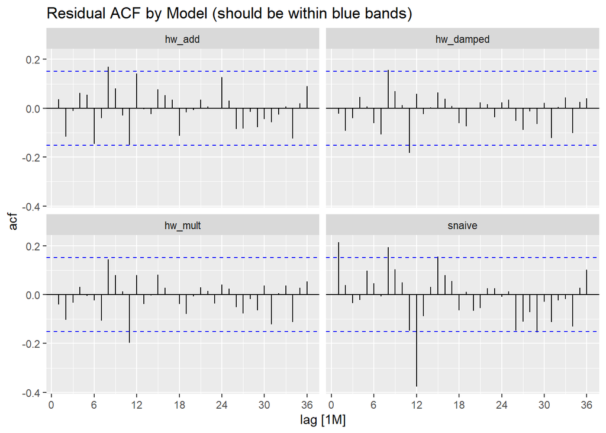

```r
# ── Residual ACF by model (reuses fit) ───────────────────────────────────────
fit |>
  select(snaive, hw_add, hw_mult, hw_damped) |>
  augment() |>
  ACF(.innov, lag_max = 36) |>
  autoplot() +
  facet_wrap(~ .model) +
  labs(title = "Residual ACF by Model (should be within blue bands)")
```

For hw_add, hw_damped, and hw_mult, virtually all autocorrelation spikes fall within the 95% confidence bands across all 36 lags, confirming that these models have removed both the trend and seasonal autocorrelation from the series. The snaive panel, by contrast, shows several significant spikes — most notably around lags 11–12, indicating that the naïve model’s residuals are correlated. This reinforces the conclusion that the ETS seasonal models, despite their MASE > 1 on the validation set, are better specified models than the naïve benchmark.

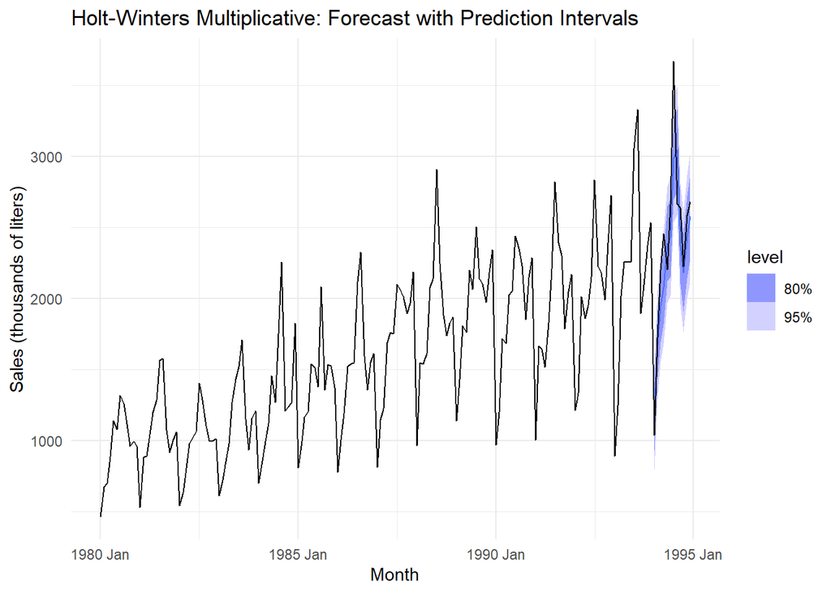

```r
# SECTION 7: PREDICTION INTERVALS
# ══════════════════════════════════════════════════════════════════════════════

# ── Theoretical prediction intervals (reuses best_fit — no refitting!) ────────
fc_best <- best_fit |> forecast(h = 12)

fc_best |>
  autoplot(red, level = c(80, 95)) +
  labs(title = "Holt-Winters Multiplicative: Forecast with Prediction Intervals",
       y = "Sales (thousands of liters)") +
  theme_minimal()
```

```r
# The 80% and 95% bands show the range of plausible future values
```

The forecast plot shows the Holt-Winters Multiplicative model’s 12-month-ahead forecast for 1994, surrounded by 80% and 95% theoretical prediction intervals. The intervals are constructed assuming normally distributed errors and widen modestly as the forecast horizon extends, reflecting compounding uncertainty.

```r
# ── Empirical prediction intervals (from Baregg framework) ────────────────────
validation_errors <- valid$Red - fc_best$.mean

cat("\nEmpirical Prediction Interval (from validation errors):\n")
```

```
##
## Empirical Prediction Interval (from validation errors):
```

```r
cat("5th percentile:", quantile(validation_errors, 0.05), "\n")
```

```
## 5th percentile: -271.6345
```

```r
cat("95th percentile:", quantile(validation_errors, 0.95), "\n")
```

```
## 95th percentile: 516.0406
```

```r
cat("This means: the true value is typically between",
    round(quantile(validation_errors, 0.05)), "and",
    round(quantile(validation_errors, 0.95)),
    "units from the forecast.\n")
```

```
## This means: the true value is typically between -272 and 516 units from the forecast.
```

## Conclusion

### Step 6: Recommend

```r
# SECTION 8: THE DEPLOYMENT DECISION
# ══════════════════════════════════════════════════════════════════════════════

# Step 1: Does it beat the benchmark?
mase_val <- acc$MASE[acc$.model == "hw_mult"]
cat("1. MASE =", round(mase_val, 3), "->",
    ifelse(mase_val < 1, "BEATS seasonal naive", "LOSES to seasonal naive"), "\n")
```

```
## 1. MASE = 1.21 -> LOSES to seasonal naive
```

```r
# Step 2: Are residuals white noise? (reuses lb_result from Section 6)
cat("2. Ljung-Box p-value =", round(lb_result$lb_pvalue, 4), "->",
    ifelse(lb_result$lb_pvalue > 0.05,
           "Residuals are white noise",
           "Residuals have structure"), "\n")
```

```
## 2. Ljung-Box p-value = 0.6003 -> Residuals are white noise
```

```r
# Step 3: Is bias acceptable?
me_val <- acc$ME[acc$.model == "hw_mult"]
cat("3. ME =", round(me_val, 1), "->",
    ifelse(abs(me_val) < 100,
           "Low bias",
           "Notable bias -- investigate direction"), "\n")
```

```
## 3. ME = 121 -> Notable bias -- investigate direction
```

```r
cat("\n")
```

```r
# Step 4: Final recommendation
if (mase_val < 1 & lb_result$lb_pvalue > 0.05) {
  cat("RECOMMENDATION: Model is adequate for deployment.\n")
  cat("Monitor forecast errors monthly and refit quarterly.\n")
} else if (mase_val < 1 & lb_result$lb_pvalue <= 0.05) {
  cat("RECOMMENDATION: Model beats benchmark but residuals have structure.\n")
  cat("Consider: (a) try auto ETS, (b) add ARIMA (Ch7), (c) investigate outliers.\n")
} else {
  cat("RECOMMENDATION: Model does not beat seasonal naive. Do not deploy.\n")
}
```

```
## RECOMMENDATION: Model does not beat seasonal naive. Do not deploy.
```

### How would I do next to improve this model?

I would try the following to improve the forecast: a. I would remove the few large spikes in the year 1984, 1985, and the 1990s as seen in the residuals plot. b. The L-jung p-test suggest that the noise is random, meaning the ETS model can’t get better, So I would try more advanced model like ARIMA. c. I would also add external variables like inflation, weather, and economic conditions.